# Taller de agentes y problemas de búsqueda

Demostración · De los datos al problema de búsqueda

## Propósito

Partimos de los datos de un entorno para formular un problema de búsqueda y resolverlo con dos implementaciones que acompañan la bibliografía del curso:

- **AIPython**, el código ejecutable de *Artificial Intelligence: Foundations of Computational Agents* de David Poole y Alan Mackworth.
- **aima-python**, la implementación de referencia de *Artificial Intelligence: A Modern Approach* de Stuart Russell y Peter Norvig.

No programaremos BFS, DFS ni costo uniforme. El trabajo importante será describir la tarea del agente: sus estados, acciones, transiciones, objetivo y criterio de calidad de una solución.

## 1. Un entorno en una tabla

Un agente de reparto debe llevar un insumo desde `Base` hasta `Servidor`. Cada fila representa una acción posible y su costo.

```python
import sys
from pathlib import Path

import matplotlib.pyplot as plt
import networkx as nx
import pandas as pd

RAIZ_REPOSITORIO = Path.cwd().resolve().parents[1]
sys.path.insert(0, str(RAIZ_REPOSITORIO / ".tools/aima-python"))
sys.path.insert(0, str(RAIZ_REPOSITORIO / ".tools/aipython-src/aipython"))

from aima.search import Problem, breadth_first_graph_search, depth_first_graph_search, uniform_cost_search
from searchGeneric import AStarSearcher, Searcher
from searchProblem import Arc, Search_problem_from_explicit_graph

ARISTAS = "datos/demo_mensajero.csv"
INICIAL = "Base"
OBJETIVO = "Servidor"

df = pd.read_csv(ARISTAS)
df.head()
```

|  | origen | destino | costo |
| --- | --- | --- | --- |
| 0 | Base | Recepción | 2 |
| 1 | Base | Archivo | 1 |
| 2 | Recepción | Laboratorio | 2 |
| 3 | Archivo | Laboratorio | 4 |
| 4 | Archivo | Taller | 1 |

Antes de resolver, formulemos el problema.

| Componente | Decisión para este caso |
| --- | --- |
| Agente | Repartidor autónomo |
| Estado | Ubicación actual del agente |
| Estado inicial | `Base` |
| Acciones | Trasladarse por una conexión saliente habilitada |
| Transición | La acción lleva al destino indicado en la tabla |
| Objetivo | `Servidor` |
| Costo | Tiempo de traslado asociado a cada conexión |

## 2. Dibujar el entorno

El grafo es una forma de **ver** el espacio de estados; la tabla sigue siendo la fuente de datos del problema.

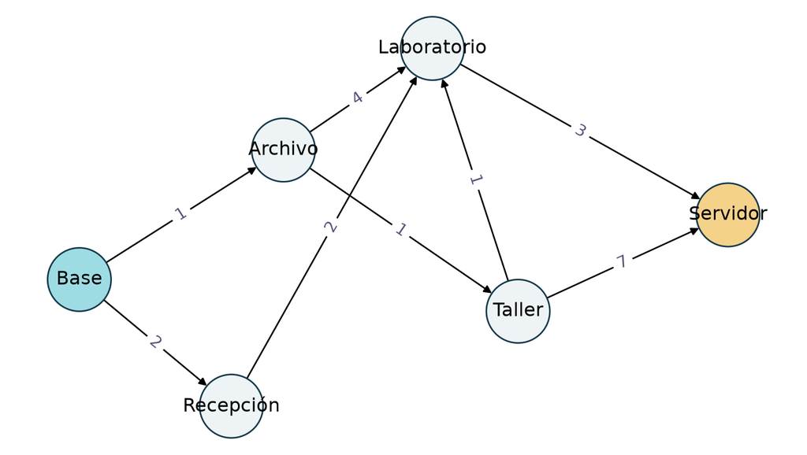

```python
grafo = nx.from_pandas_edgelist(
    df,
    source="origen",
    target="destino",
    edge_attr="costo",
    create_using=nx.DiGraph,
)

posicion = nx.spring_layout(grafo, seed=14)
colores = ["#9edce3" if nodo == INICIAL else "#f4d28a" if nodo == OBJETIVO else "#eef4f5" for nodo in grafo.nodes]
plt.figure(figsize=(9, 5))
nx.draw_networkx(grafo, posicion, node_color=colores, edgecolors="#14384a", node_size=1650, arrows=True)
nx.draw_networkx_edge_labels(grafo, posicion, edge_labels=nx.get_edge_attributes(grafo, "costo"), font_color="#5d5179")
plt.axis("off")
plt.show()
```

## 3. Russell y Norvig · Modelar un `Problem`

`aima-python` utiliza la misma interfaz de formulación que presenta el libro: definimos las acciones disponibles, el resultado de una acción y el costo del camino. La búsqueda queda en las funciones de la biblioteca.

```python
class ProblemaReparto(Problem):
    def __init__(self, aristas, inicial, objetivo):
        super().__init__(initial=inicial, goal=objetivo)
        self.salidas = aristas.groupby("origen")
        self.costos = {(fila.origen, fila.destino): fila.costo for fila in aristas.itertuples(index=False)}

    def actions(self, estado):
        if estado not in self.salidas.groups:
            return []
        return self.salidas.get_group(estado)["destino"].tolist()

    def result(self, estado, accion):
        return accion

    def path_cost(self, costo_acumulado, estado, accion, siguiente_estado):
        return costo_acumulado + self.costos[(estado, accion)]

problema_rn = ProblemaReparto(df, INICIAL, OBJETIVO)
```

Ahora aplicamos directamente las búsquedas no informadas del libro.

```python
def resumir_nodo(nombre, nodo):
    camino = [n.state for n in nodo.path()]
    return {"biblioteca": "aima-python", "estrategia": nombre, "camino": " → ".join(camino), "pasos": nodo.depth, "costo": nodo.path_cost}

resultados_rn = [
    resumir_nodo("BFS", breadth_first_graph_search(problema_rn)),
    resumir_nodo("DFS", depth_first_graph_search(problema_rn)),
    resumir_nodo("Costo uniforme", uniform_cost_search(problema_rn)),
]

pd.DataFrame(resultados_rn)
```

|  | biblioteca | estrategia | camino | pasos | costo |
| --- | --- | --- | --- | --- | --- |
| 0 | aima-python | BFS | Base → Recepción → Laboratorio → Servidor | 3 | 7 |
| 1 | aima-python | DFS | Base → Archivo → Taller → Servidor | 3 | 9 |
| 2 | aima-python | Costo uniforme | Base → Archivo → Taller → Laboratorio → Servidor | 4 | 6 |

## 4. Poole y Mackworth · El buscador genérico

En AIPython el problema explícito se construye con nodos y arcos. `Searcher` implementa la búsqueda genérica con frontera LIFO (profundidad). `AStarSearcher`, si la heurística vale cero, prioriza únicamente el costo acumulado: es la forma de búsqueda de menor costo del esquema genérico de Poole.

```python
arcos = [
    Arc(fila.origen, fila.destino, cost=fila.costo, action=fila.destino)
    for fila in df.itertuples(index=False)
]

problema_poole = Search_problem_from_explicit_graph(
    title="Agente de reparto",
    nodes=set(df["origen"]) | set(df["destino"]),
    arcs=arcos,
    start=INICIAL,
    goals={OBJETIVO},
    hmap={},  # h(n)=0: la prioridad es sólo el costo acumulado
)

camino_dfs_poole = Searcher(problema_poole).search()
camino_uc_poole = AStarSearcher(problema_poole).search()

pd.DataFrame([
    {"biblioteca": "AIPython", "estrategia": "DFS genérica", "camino": " → ".join(reversed(list(camino_dfs_poole.nodes()))), "costo": camino_dfs_poole.cost},
    {"biblioteca": "AIPython", "estrategia": "Menor costo (h = 0)", "camino": " → ".join(reversed(list(camino_uc_poole.nodes()))), "costo": camino_uc_poole.cost},
])
```

```
Solution: Base
   --Recepción--> Recepción
   --Laboratorio--> Laboratorio
   --Servidor--> Servidor (cost: 7)
 4 paths have been expanded and 1 paths remain in the frontier
Solution: Base
   --Archivo--> Archivo
   --Taller--> Taller
   --Laboratorio--> Laboratorio
   --Servidor--> Servidor (cost: 6)
 8 paths have been expanded and 3 paths remain in the frontier
```

|  | biblioteca | estrategia | camino | costo |
| --- | --- | --- | --- | --- |
| 0 | AIPython | DFS genérica | Base → Recepción → Laboratorio → Servidor | 7 |
| 1 | AIPython | Menor costo (h = 0) | Base → Archivo → Taller → Laboratorio → Servidor | 6 |

## 5. Lectura del resultado

- Con **BFS**, el criterio es llegar con la menor cantidad de acciones.
- Con **DFS**, el resultado depende del orden de exploración y no garantiza ni menos pasos ni menor costo.
- Con **costo uniforme**, el agente prioriza el menor costo acumulado, aunque recorra más conexiones.
- Las dos bibliotecas ofrecen el algoritmo: nosotros construimos el problema que el agente debe resolver.

La actividad siguiente presenta otro entorno. Allí el foco será decidir qué estrategia tiene sentido para la tarea antes de ejecutar una o dos líneas de código.